# Bayesian modeling and prediction for movies

## Setup

### Load packages

```r
library(ggplot2)
library(dplyr)
library(statsr)
library(BAS)
library(GGally)
```

### Load data

```r
load("movies.Rdata")
```

## Part 1: Data

The dataset “movies” is comprised of 651 randomly sampled movies produced and released before 2016. This dataset includes information from both [Rotten Tomatoes](https://www.rottentomatoes.com/) and [IMDb](http://www.imdb.com/).

Rotten Tomatoes is a website launched in August 1998 devoted to film reviews and news; it is widely known as a film review aggregator. Coverage now includes TV content as well. The name derives from the practice of audiences throwing rotten tomatoes when disapproving of a poor stage performance. The company was created by Senh Duong and since January 2010 has been owned by Flixster, which itself was acquired in 2011 by Warner Bros.

The Internet Movie Database (abbreviated IMDb) is an online database of information related to films, television programs and video games, including cast, production crew, fictional characters, biographies, plot summaries, trivia and reviews. Actors and crew can post their own résumé and upload photos of themselves for a yearly fee. U.S. users can view over 6000 movies and television shows from CBS, Sony, and various independent filmmakers.

This dataset contains information about the type of the movie, genre, runtime, studio, release, critics rating, director and so on.

### Sampling Design

The target population of this dataset is U.S. movies theatrically released between 1970 and 2014. The movies composing this dataset are randomly sampled from two famous Internet databases for movies : Rotten Tomatoes and IMDb.

#### Scope of Inference

From what is described in the points above, it seems pretty clear that the “movies” dataset should be considered the result of an observational retrospective study that uses a random sampling design to select a representative sample from U.S. movies.

#### Generalizability

As it is, our results should be generalizable to all U.S. movies released between 1970 and 2014.

#### Causality

As is well-known, making causal conclusions based on observational data is not recommended. Observational studies are only sufficient to show associations.

## Part 2: Data manipulation

First we create the new variable *feature_film* which characterizes if a movie is a feature film or not.

```r
movies_ext <- movies %>% mutate(feature_film = ifelse(title_type == "Feature Film", "yes", "no")) %>% mutate(feature_film = factor(feature_film, levels = c("yes", "no")))
```

Then we go on to create the new variable *drama* which characterizes if a movie is a drama or not.

```r
movies_ext <- movies_ext %>% mutate(drama = ifelse(genre == "Drama", "yes", "no")) %>% mutate(drama = factor(drama, levels = c("yes", "no")))
```

Next, we create the new variabel *mpaa_rating_R* which characterizes if a movie is R-rated or not.

```r
movies_ext <- movies_ext %>% mutate(mpaa_rating_R = ifelse(mpaa_rating == "R", "yes", "no")) %>% mutate(mpaa_rating_R = factor(mpaa_rating_R, levels = c("yes", "no")))
```

Finally, we create two new variables *oscar_season* and *summer_season* which characterize if a movie is released in November, October, December, or released in May, June, July, August respectively.

```r
movies_ext <- movies_ext %>% mutate(oscar_season = ifelse(thtr_rel_month %in% c(10, 11, 12), "yes", "no")) %>% mutate(oscar_season = factor(oscar_season, levels = c("yes", "no")))
movies_ext <- movies_ext %>% mutate(summer_season = ifelse(thtr_rel_month %in% c(5, 6, 7, 8), "yes", "no")) %>% mutate(summer_season = factor(summer_season, levels = c("yes", "no")))
```

## Part 3: Exploratory data analysis

Let’s begin by plotting a histogram of the response variable.

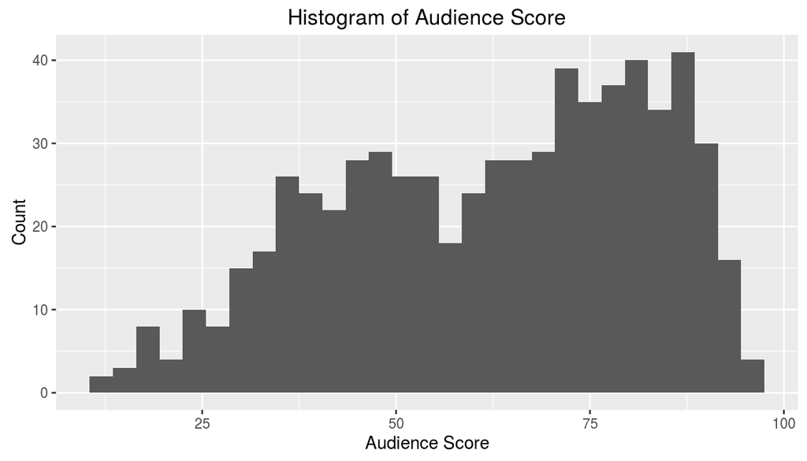

```r
ggplot(movies_ext, aes(x = audience_score)) + geom_histogram(binwidth = 3) + xlab("Audience Score") + ylab("Count") + ggtitle("Histogram of Audience Score")
```

```r
summary(movies_ext$audience_score)
```

```
##    Min. 1st Qu.  Median    Mean 3rd Qu.    Max.
##   11.00   46.00   65.00   62.36   80.00   97.00
```

The distribution of the *audience_score* variable exhibits a left skew and may be uni- or multimodal.

### Boxplots of Response vs. Categorical Predictors

Now, we are able to begin our exploratory data analysis, first we will use boxplots to visualize how our categorical variables of interest interact with the response variable.

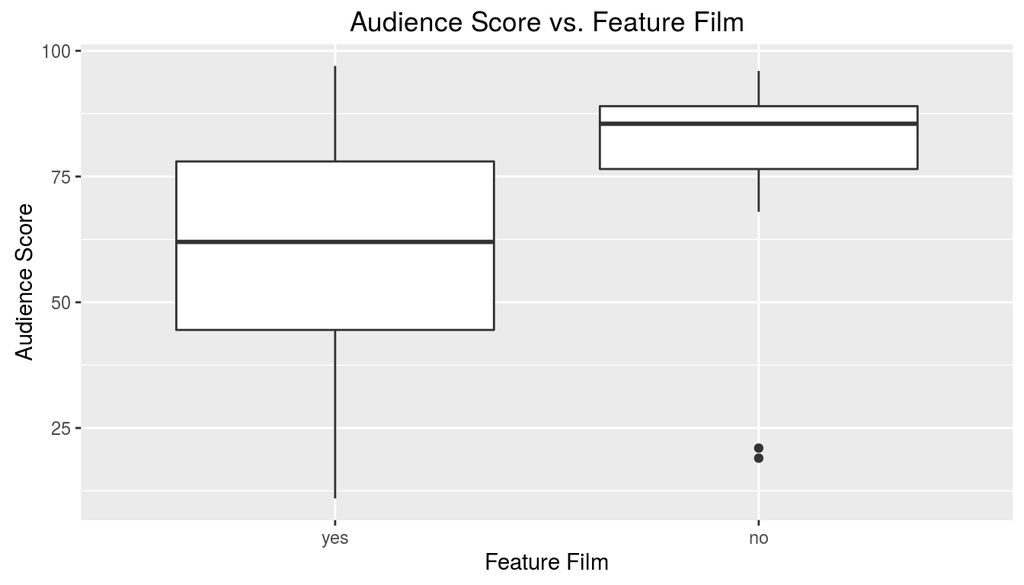

```r
ggplot(movies_ext, aes(x = feature_film, y = audience_score)) + geom_boxplot() + xlab("Feature Film") + ylab("Audience Score") + ggtitle("Audience Score vs. Feature Film")
```

```r
movies_ext %>% group_by(feature_film) %>% summarise(median_score = median(audience_score), iqr_score = IQR(audience_score))
```

```
## Source: local data frame [2 x 3]
##
##   feature_film median_score iqr_score
##         (fctr)        (dbl)     (dbl)
## 1          yes         62.0      33.5
## 2           no         85.5      12.5
```

It seems that the variables *feature_film* and the response *audience_score* are in some way associated.

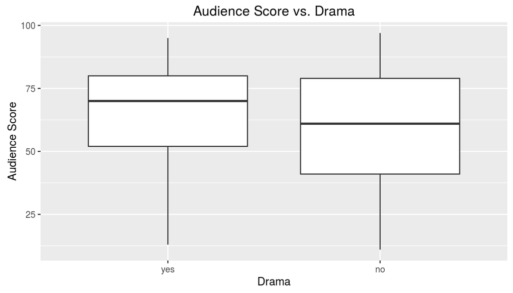

```r
ggplot(movies_ext, aes(x = drama, y = audience_score)) + geom_boxplot() + xlab("Drama") + ylab("Audience Score") + ggtitle("Audience Score vs. Drama")
```

```r
movies_ext %>% group_by(drama) %>% summarise(median_score = median(audience_score), iqr_score = IQR(audience_score))
```

```
## Source: local data frame [2 x 3]
##
##    drama median_score iqr_score
##   (fctr)        (dbl)     (dbl)
## 1    yes           70        28
## 2     no           61        38
```

Here, it is not so clear that the variables *drama* and the response *audience_score* are associated. The variable *drama* may not be a very good predictor for the response.

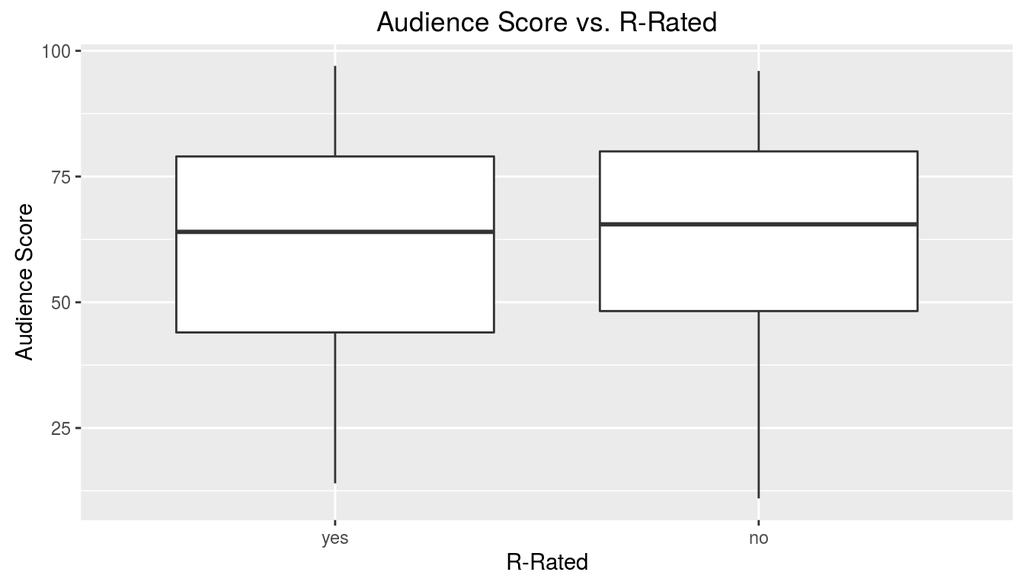

```r
ggplot(movies_ext, aes(x = mpaa_rating_R, y = audience_score)) + geom_boxplot() + xlab("R-Rated") + ylab("Audience Score") + ggtitle("Audience Score vs. R-Rated")
```

```r
movies_ext %>% group_by(mpaa_rating_R) %>% summarise(median_score = median(audience_score), iqr_score = IQR(audience_score))
```

```
## Source: local data frame [2 x 3]
##
##   mpaa_rating_R median_score iqr_score
##          (fctr)        (dbl)     (dbl)
## 1           yes         64.0     35.00
## 2            no         65.5     31.75
```

Here also, it is not so clear that the variables *mpaa_rating_R* and the response *audience_score* are associated. The variable *mpaa_rating_R* may not be a good predictor for the response.

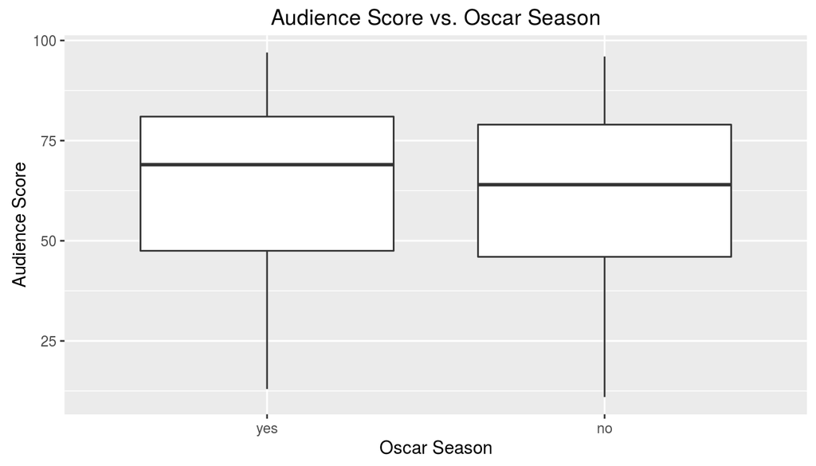

```r
ggplot(movies_ext, aes(x = oscar_season, y = audience_score)) + geom_boxplot() + xlab("Oscar Season") + ylab("Audience Score") + ggtitle("Audience Score vs. Oscar Season")
```

```r
movies_ext %>% group_by(oscar_season) %>% summarise(median_score = median(audience_score), iqr_score = IQR(audience_score))
```

```
## Source: local data frame [2 x 3]
##
##   oscar_season median_score iqr_score
##         (fctr)        (dbl)     (dbl)
## 1          yes           69      33.5
## 2           no           64      33.0
```

Here also, it is not so clear that the variables *oscar_season* and the response *audience_score* are associated. The variable *oscar_season* may not be a good predictor for the response.

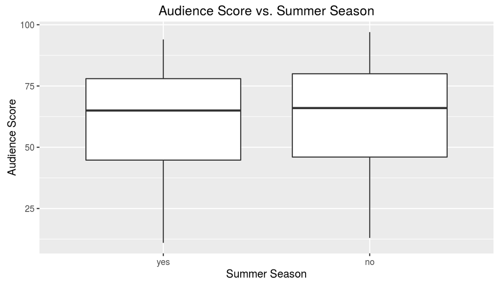

```r
ggplot(movies_ext, aes(x = summer_season, y = audience_score)) + geom_boxplot() + xlab("Summer Season") + ylab("Audience Score") + ggtitle("Audience Score vs. Summer Season")
```

```r
movies_ext %>% group_by(summer_season) %>% summarise(median_score = median(audience_score), iqr_score = IQR(audience_score))
```

```
## Source: local data frame [2 x 3]
##
##   summer_season median_score iqr_score
##          (fctr)        (dbl)     (dbl)
## 1           yes           65     33.25
## 2            no           66     34.00
```

Here again, it is not so clear that the variables *summer_season* and the response *audience_score* are associated. The variable *summer_season* may not be a good predictor for the response.

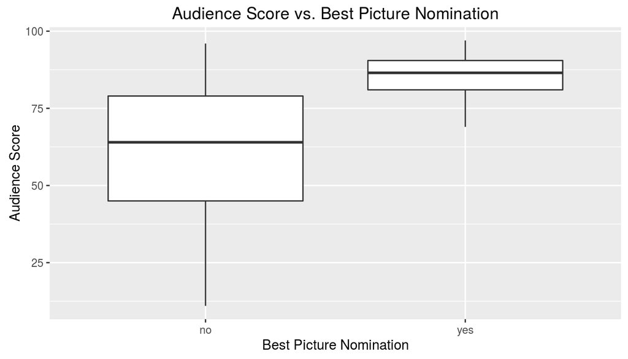

```r
ggplot(movies_ext, aes(x = best_pic_nom, y = audience_score)) + geom_boxplot() + xlab("Best Picture Nomination") + ylab("Audience Score") + ggtitle("Audience Score vs. Best Picture Nomination")
```

```r
movies_ext %>% group_by(best_pic_nom) %>% summarise(median_score = median(audience_score), iqr_score = IQR(audience_score))
```

```
## Source: local data frame [2 x 3]
##
##   best_pic_nom median_score iqr_score
##         (fctr)        (dbl)     (dbl)
## 1           no         64.0      34.0
## 2          yes         86.5       9.5
```

It seems that the variables *best_pic_nom* and the response *audience_score* are in some way associated.

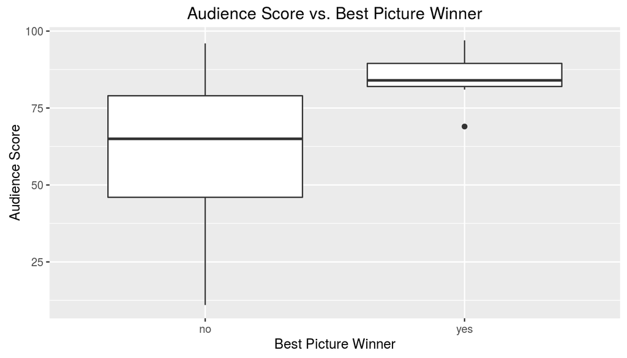

```r
ggplot(movies_ext, aes(x = best_pic_win, y = audience_score)) + geom_boxplot() + xlab("Best Picture Winner") + ylab("Audience Score") + ggtitle("Audience Score vs. Best Picture Winner")
```

```r
movies_ext %>% group_by(best_pic_win) %>% summarise(median_score = median(audience_score), iqr_score = IQR(audience_score))
```

```
## Source: local data frame [2 x 3]
##
##   best_pic_win median_score iqr_score
##         (fctr)        (dbl)     (dbl)
## 1           no           65      33.0
## 2          yes           84       7.5
```

Again, it seems that the variables *best_pic_nom* and the response *audience_score* are in some way associated.

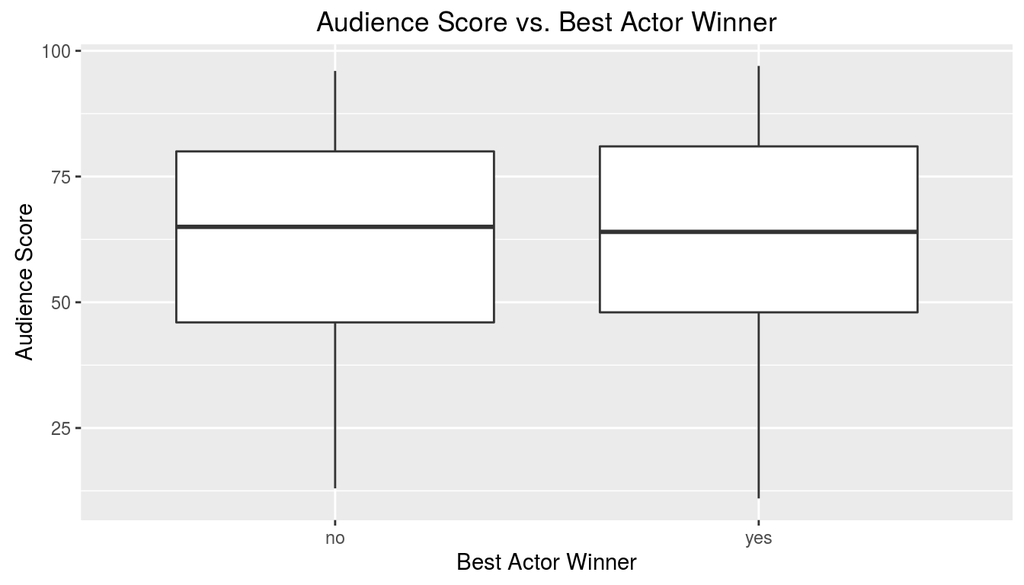

```r
ggplot(movies_ext, aes(x = best_actor_win, y = audience_score)) + geom_boxplot() + xlab("Best Actor Winner") + ylab("Audience Score") + ggtitle("Audience Score vs. Best Actor Winner")
```

```r
movies_ext %>% group_by(best_actor_win) %>% summarise(median_score = median(audience_score), iqr_score = IQR(audience_score))
```

```
## Source: local data frame [2 x 3]
##
##   best_actor_win median_score iqr_score
##           (fctr)        (dbl)     (dbl)
## 1             no           65        34
## 2            yes           64        33
```

Here, it is not so clear that the variables *best_actor_win* and the response *audience_score* are associated. The variable *best_actor_win* may not be a good predictor for the response.

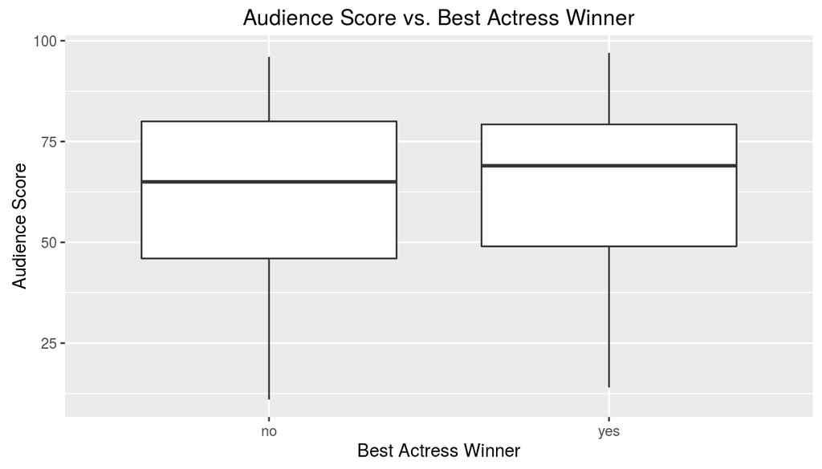

```r
ggplot(movies_ext, aes(x = best_actress_win, y = audience_score)) + geom_boxplot() + xlab("Best Actress Winner") + ylab("Audience Score") + ggtitle("Audience Score vs. Best Actress Winner")
```

```r
movies_ext %>% group_by(best_actress_win) %>% summarise(median_score = median(audience_score), iqr_score = IQR(audience_score))
```

```
## Source: local data frame [2 x 3]
##
##   best_actress_win median_score iqr_score
##             (fctr)        (dbl)     (dbl)
## 1               no           65     34.00
## 2              yes           69     30.25
```

Here also, it is not so clear that the variables *best_actress_win* and the response *audience_score* are associated. The variable *best_actress_win* may not be a good predictor for the response.

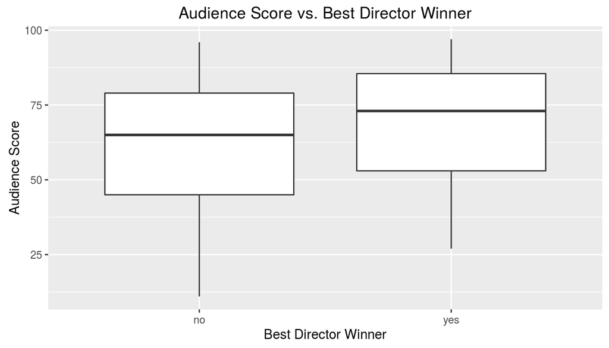

```r
ggplot(movies_ext, aes(x = best_dir_win, y = audience_score)) + geom_boxplot() + xlab("Best Director Winner") + ylab("Audience Score") + ggtitle("Audience Score vs. Best Director Winner")
```

```r
movies_ext %>% group_by(best_dir_win) %>% summarise(median_score = median(audience_score), iqr_score = IQR(audience_score))
```

```
## Source: local data frame [2 x 3]
##
##   best_dir_win median_score iqr_score
##         (fctr)        (dbl)     (dbl)
## 1           no           65      34.0
## 2          yes           73      32.5
```

Here also, it is not so clear that the variables *best_dir_win* and the response *audience_score* are associated. The variable *best_dir_win* may not be a very good predictor for the response.

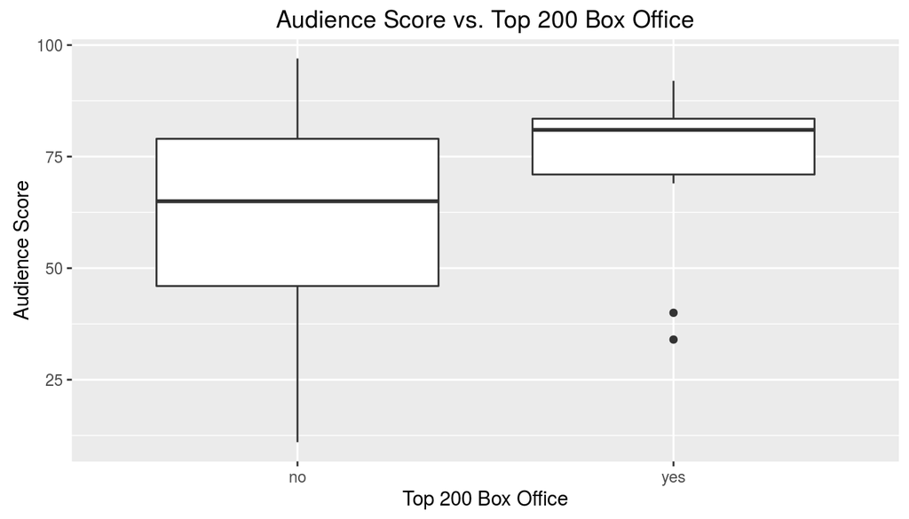

```r
ggplot(movies_ext, aes(x = top200_box, y = audience_score)) + geom_boxplot() + xlab("Top 200 Box Office") + ylab("Audience Score") + ggtitle("Audience Score vs. Top 200 Box Office")
```

```r
movies_ext %>% group_by(top200_box) %>% summarise(median_score = median(audience_score), iqr_score = IQR(audience_score))
```

```
## Source: local data frame [2 x 3]
##
##   top200_box median_score iqr_score
##       (fctr)        (dbl)     (dbl)
## 1         no           65      33.0
## 2        yes           81      12.5
```

It seems that the variables *top200_box* and the response *audience_score* are in some way associated.

### Scatterplots of Response vs. Numerical Predictors

Now, we will use scatterplots to visualize how our numerical variables of interest interact with our response variable.

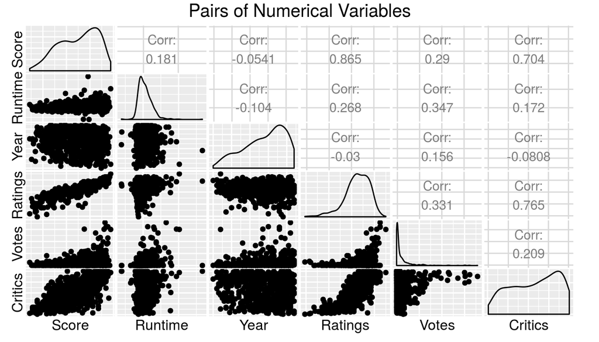

```r
ggpairs(movies_ext, columns = c(18, 4, 7, 13, 14, 16), axisLabels = "none", columnLabels = c("Score", "Runtime", "Year", "Ratings", "Votes", "Critics"), title = "Pairs of Numerical Variables")
```

As we may see above, the correlations between predictors are not very high (bar *imdb_rating* and *critics_score*), which is a good thing when modeling with linear regression as it helps avoiding collinearity.

### Conclusion

As our previous plots show, the variables *mpaa_rating_R*, *oscar_season*, *summer_season*, *best_actor_win*, *best_actress_win* and *runtime* do not seem to be particularly relevant. However, we will keep them in our modeling phase to have a better answer to the research question.

```r
movies_ext_reg <- movies_ext %>% select(audience_score, feature_film, drama, runtime, mpaa_rating_R, thtr_rel_year, oscar_season, summer_season, imdb_rating, imdb_num_votes, critics_score, best_pic_nom, best_pic_win, best_actor_win, best_actress_win, best_dir_win, top200_box)
```

## Part 4: Modeling

We may recall that under the model

$$y_i = \beta_0 + \sum_j^p\beta_j \cdot x_{ij} + \epsilon_i$$

if $\epsilon_i \sim N(0, \sigma^2)$ and the reference prior $p(\beta_0,\cdots,\beta_p,\sigma^2) \propto 1/\sigma^2$ is used, then the Bayesian posterior means and standard deviations will be equal to the frequentist estimates and standard errors respectively.

### Model Diagnostics

As the Bayesian model assumes that the errors are normally distributed with a constant variance, we have to check this assumption by examining the distribution of the residuals for the model. If the residuals are highly non-normal or skewed, the assumption is violated and any subsequent inference will not be valid.

First, we will define a function which will help us to visualize QQ-plots.

```r
ggQQ <- function(LM) # argument: a linear model
{
    y <- quantile(LM$resid[!is.na(LM$resid)], c(0.25, 0.75))
    x <- qnorm(c(0.25, 0.75))
    slope <- diff(y) / diff(x)
    int <- y[1L] - slope * x[1L]
    p <- ggplot(LM, aes(sample = .resid)) +
        stat_qq(alpha = 0.5) +
        geom_abline(slope = slope, intercept = int, color = "red") + xlab("Theoretical Quantiles") + ylab("Sample Quantiles")

    return(p)
}
```

Let’s have a look a the distribution and at the QQ-plot of the residuals.

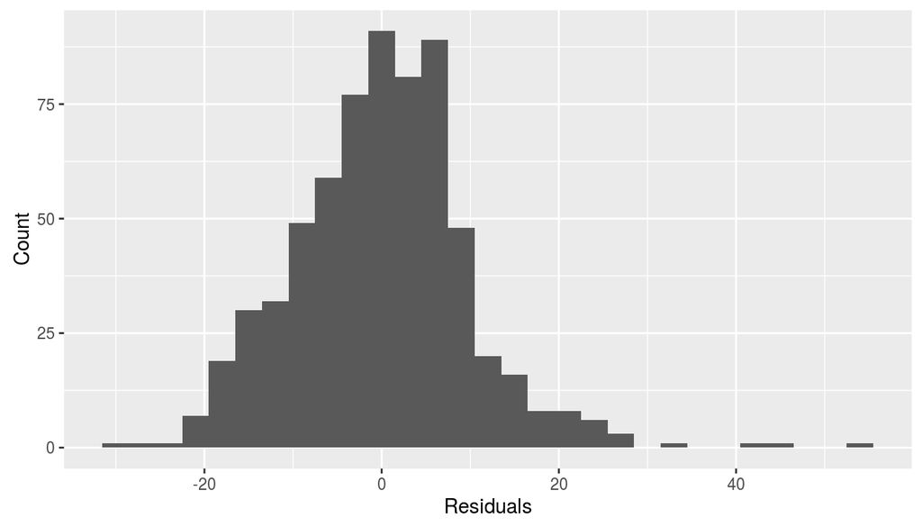

```r
m_audience <- lm(audience_score ~ ., data = movies_ext_reg)
ggplot(data = m_audience, aes(x = .resid)) +
  geom_histogram(binwidth = 3) +
  xlab("Residuals") + ylab("Count")
```

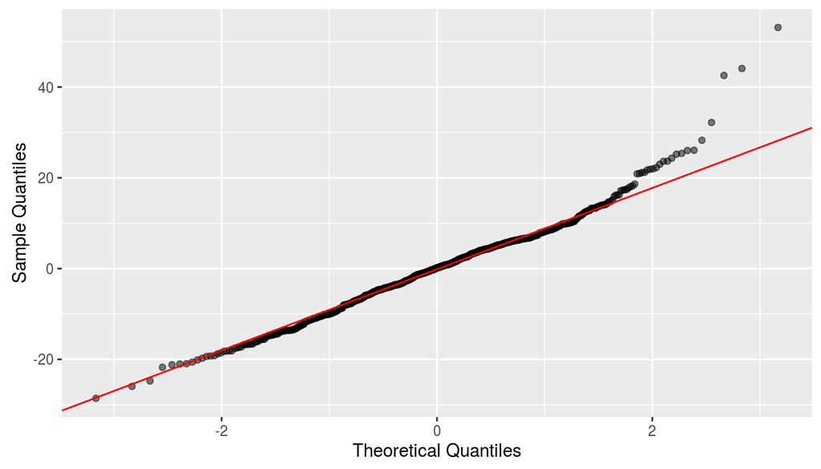

```r
ggQQ(m_audience)
```

Based on the plots above it does seem that the residuals exhibit a moderate right skew which may render our inference less pertinent. We have to keep that fact in mind when we conclude our analysis.

### Baseline Model

Let’s take a look at a summary for our baseline model.

```r
summary(m_audience)
```

```
##
## Call:
## lm(formula = audience_score ~ ., data = movies_ext_reg)
##
## Residuals:
##     Min      1Q  Median      3Q     Max
## -28.594  -6.156   0.157   5.909  53.125
##
## Coefficients:
##                       Estimate Std. Error t value Pr(>|t|)
## (Intercept)          1.224e+02  7.720e+01   1.585  0.11338
## feature_filmno       2.248e+00  1.687e+00   1.332  0.18323
## dramano             -1.292e+00  8.766e-01  -1.474  0.14087
## runtime             -5.614e-02  2.415e-02  -2.324  0.02042 *
## mpaa_rating_Rno      1.444e+00  8.127e-01   1.777  0.07598 .
## thtr_rel_year       -7.657e-02  3.835e-02  -1.997  0.04628 *
## oscar_seasonno       5.333e-01  9.967e-01   0.535  0.59280
## summer_seasonno     -9.106e-01  9.493e-01  -0.959  0.33778
## imdb_rating          1.472e+01  6.067e-01  24.258  < 2e-16 ***
## imdb_num_votes       7.234e-06  4.523e-06   1.600  0.11019
## critics_score        5.748e-02  2.217e-02   2.593  0.00973 **
## best_pic_nomyes      5.321e+00  2.628e+00   2.025  0.04330 *
## best_pic_winyes     -3.212e+00  4.610e+00  -0.697  0.48624
## best_actor_winyes   -1.544e+00  1.179e+00  -1.310  0.19068
## best_actress_winyes -2.198e+00  1.304e+00  -1.686  0.09229 .
## best_dir_winyes     -1.231e+00  1.728e+00  -0.713  0.47630
## top200_boxyes        8.478e-01  2.782e+00   0.305  0.76067
## ---
## Signif. codes:  0 '***' 0.001 '**' 0.01 '*' 0.05 '.' 0.1 ' ' 1
##
## Residual standard error: 9.975 on 633 degrees of freedom
##   (1 observation deleted due to missingness)
## Multiple R-squared:  0.763,  Adjusted R-squared:  0.757
## F-statistic: 127.3 on 16 and 633 DF,  p-value: < 2.2e-16
```

As you may see from the summary above, many coefficients of independent variables are not statistically significant.

### Bayesian Model Averaging

We will now use Bayesian Model Averaging (BMA), in which multiple models are averaged to obtain posteriors of coefficients and predictions from new data.

```r
bma_audience <- bas.lm(audience_score ~ ., data = na.omit(movies_ext_reg), prior = "BIC", modelprior = uniform(), method = "MCMC")
bma_audience
```

```
##
## Call:
## bas.lm(formula = audience_score ~ ., data = na.omit(movies_ext_reg),     prior = "BIC", modelprior = uniform(), method = "MCMC")
##
##
##  Marginal Posterior Inclusion Probabilities:
##           Intercept       feature_filmno              dramano
##             1.00000              0.06293              0.04077
##             runtime      mpaa_rating_Rno        thtr_rel_year
##             0.46907              0.19758              0.08784
##      oscar_seasonno      summer_seasonno          imdb_rating
##             0.07278              0.07794              1.00000
##      imdb_num_votes        critics_score      best_pic_nomyes
##             0.05549              0.89102              0.12843
##     best_pic_winyes    best_actor_winyes  best_actress_winyes
##             0.03749              0.14228              0.13916
##     best_dir_winyes        top200_boxyes
##             0.06464              0.04523
```

```r
summary(bma_audience)
```

```
##      Intercept feature_filmno dramano runtime mpaa_rating_Rno
## [1,]         1              0       0       1               0
## [2,]         1              0       0       0               0
## [3,]         1              0       0       0               0
## [4,]         1              0       0       0               1
## [5,]         1              0       0       1               1
##      thtr_rel_year oscar_seasonno summer_seasonno imdb_rating
## [1,]             0              0               0           1
## [2,]             0              0               0           1
## [3,]             0              0               0           1
## [4,]             0              0               0           1
## [5,]             0              0               0           1
##      imdb_num_votes critics_score best_pic_nomyes best_pic_winyes
## [1,]              0             1               0               0
## [2,]              0             1               0               0
## [3,]              0             1               0               0
## [4,]              0             1               0               0
## [5,]              0             1               0               0
##      best_actor_winyes best_actress_winyes best_dir_winyes top200_boxyes
## [1,]                 0                   0               0             0
## [2,]                 0                   0               0             0
## [3,]                 1                   0               0             0
## [4,]                 0                   0               0             0
## [5,]                 0                   0               0             0
##             BF PostProbs     R2 dim   logmarg
## [1,] 1.0000000    0.1310 0.7549   4 -3615.279
## [2,] 0.9968489    0.1306 0.7525   3 -3615.282
## [3,] 0.2543185    0.0333 0.7539   4 -3616.648
## [4,] 0.2521327    0.0330 0.7539   4 -3616.657
## [5,] 0.2391994    0.0313 0.7563   5 -3616.710
```

Here, the most likely model, which has posterior probability of 0.131, includes an intercept and the variables *runtime*, *imdb_rating* and *critics_score*.

We may also visualize the posterior distribution of the coefficients under the model averaging approach for the variables included in the most likely model.

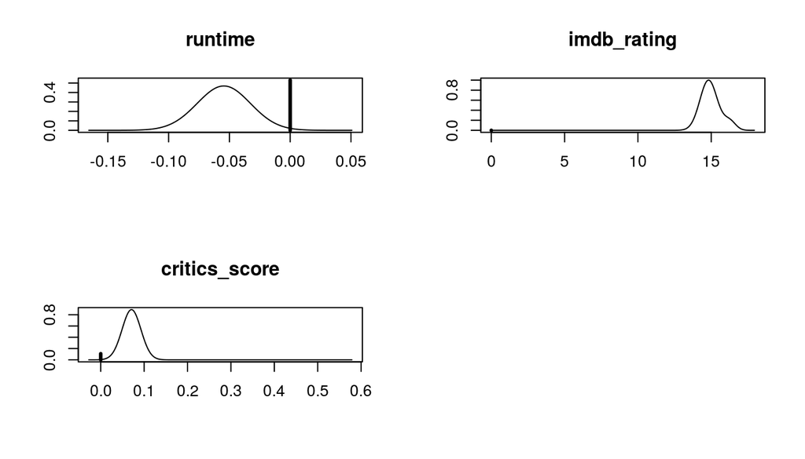

```r
par(mfrow = c(2, 2))
coef_audience <- coefficients(bma_audience)
plot(coef_audience, subset = c(4, 9, 11), ask = FALSE)
```

### Interpretation of Model Coefficients

In the table below, you’ll find the posterior means and posterior standard deviations for the variables present in the most likely model.

```r
print(data.frame("Name" = coef_audience$namesx, "Post Mean" = coef_audience$postmean, "Post SD" = coef_audience$postsd)[c(1, 4, 9, 11), ], row.names = FALSE)
```

```
##           Name   Post.Mean    Post.SD
##      Intercept 62.34769231 0.39460173
##        runtime -0.02563728 0.03116680
##    imdb_rating 14.97876188 0.72908400
##  critics_score  0.06316070 0.03014155
```

Below, you’ll also find the 95% credible intervals for these coefficients.

```r
cred_int <- confint(coef_audience)[c(4, 9, 11), ]
cred_int
```

```
##                    2.5  %    97.5  %
## runtime       -0.08238545  0.0000000
## imdb_rating   13.70422871 16.5449767
## critics_score  0.00000000  0.1052668
```

We may interpret these intervals by saying that, for example, there is a 95% chance that the audience score will increase by 13.7 to 16.5 points with every additional rating IMDb point increase. Similarly, there is a 95% chance that the audience score will increase by -0.1 to 0 points with every additional runtime minute, and finally, there is a 95% chance that the audience score will increase by 0 to 0.1 points with every additional critics score point increase.

### Outlier Detection

If we look at the residual plot of observed and fitted values under BMA, some observations (namely observations 126, 216 and 251) have large absolute residuals, it remains to see if these may be characterized as outliers.

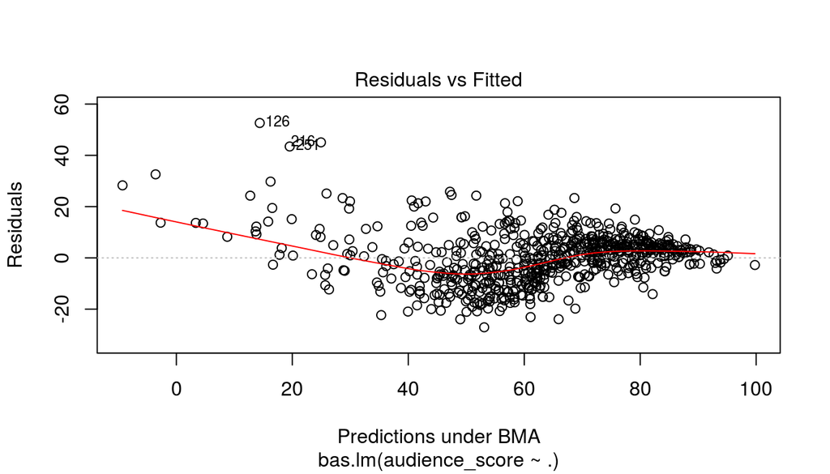

```r
plot(bma_audience, which = 1)
```

Some form of outliers selection or model averaging is needed in combination with posterior inference about the other variables.

```r
set.seed(1)
n <- nrow(na.omit(movies_ext_reg))
audience_outliers <- cbind(na.omit(movies_ext_reg), diag(1, nrow = n))
outliers_audience <- bas.lm(audience_score ~ ., data = audience_outliers, prior = "ZS-null", a = n, modelprior = tr.beta.binomial(a = 1, b = 1, trunc = n/2), method = "MCMC", initprobs = "marg-eplogp", MCMC.iterations = 500000, n.models = 2^15)
```

If we take a look at the diagnostic plot for MCMC, we see that the inclusion probabilities are in reasonable agreement, this is probably adequate for the outlier detection.

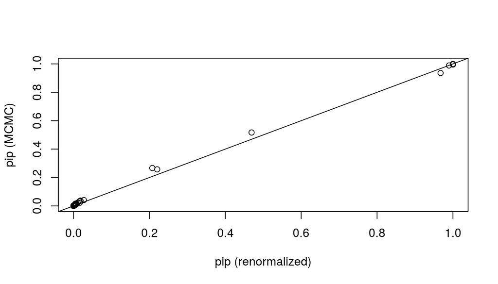

```r
diagnostics(outliers_audience, type = "pip")
```

Now, let’s have a look at which variables have high marginal inclusion probabilities.

```r
outliers_audience$namesx[outliers_audience$probne0 > 0.5]
```

```
## [1] "Intercept"   "imdb_rating" "`126`"       "`216`"       "`251`"
```

This suggests that cases 126, 216 and 251 are potential outliers. Before deciding to remove them, we need to investigate these cases and determine if there are valid reasons for why they may appear to be from a different population. But this is beyond the scope of this study.

We may also note that if we remove these cases, the hypothesis of normality of the residuals for our baseline model is much more verified.

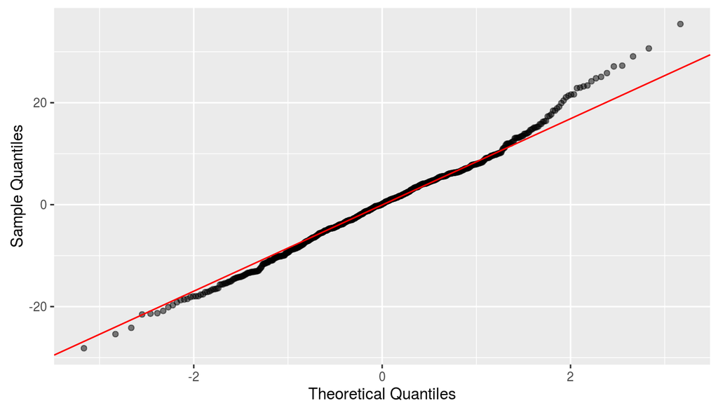

```r
m_audience_out <- lm(audience_score ~ ., data = movies_ext_reg[-c(126, 216, 251), ])
ggQQ(m_audience_out)
```

## Part 5: Prediction

The movie which audience score we will try to predict is “Captain America : Civil War”, the data about this movie is given in the following table.

```r
civil_war <- data.frame(audience_score = 90, feature_film = "yes", drama = "no", runtime = 147, mpaa_rating_R = "no", thtr_rel_year = 2016, oscar_season = "no", summer_season = "no", imdb_rating = 8.2, imdb_num_votes = 267240, critics_score = 90, best_pic_nom = "no", best_pic_win = "no", best_actor_win = "no", best_actress_win = "no", best_dir_win = "no", top200_box = "yes")
civil_war$feature_film <- factor(civil_war$feature_film, levels = c("yes", "no"))
civil_war$drama <- factor(civil_war$drama, levels = c("yes", "no"))
civil_war$mpaa_rating_R <- factor(civil_war$mpaa_rating_R, levels = c("yes", "no"))
civil_war$oscar_season <- factor(civil_war$oscar_season, levels = c("yes", "no"))
civil_war$summer_season <- factor(civil_war$summer_season, levels = c("yes", "no"))
civil_war$best_pic_nom <- factor(civil_war$best_pic_nom, levels = c("no", "yes"))
civil_war$best_pic_win <- factor(civil_war$best_pic_win, levels = c("no", "yes"))
civil_war$best_actor_win <- factor(civil_war$best_actor_win, levels = c("no", "yes"))
civil_war$best_actress_win <- factor(civil_war$best_actress_win, levels = c("no", "yes"))
civil_war$best_dir_win <- factor(civil_war$best_dir_win, levels = c("no", "yes"))
civil_war$top200_box <- factor(civil_war$top200_box, levels = c("no", "yes"))
```

The data for this movie comes from three websites : [IMDb](http://www.imdb.com/), [Rotten Tomatoes](https://www.rottentomatoes.com/) and [Box Office Mojo](http://www.boxofficemojo.com/). We will now predict the audience score with our model.

```r
BMA_pred_audience <-  predict(bma_audience, newdata = civil_war, estimator = "BMA", se.fit = TRUE, top = 100)
```

Our prediction for the audience score for “Captain America : Civil War” is 89.14/100. Actually, the real audience score of “Captain America : Civil War” (as given by Rotten Tomatoes) is 90/100 which is pretty close to our predicted score.

## Part 6: Conclusion

In conclusion, we can actually predict the popularity of a movie (as represented by the *audience_score* variable) by using the variables included in this analysis.

This assertion comes from the fact that we were able to build a bayesian linear model to predict our response with the aforementioned variables as predictors. We used Bayesian Model Averaging to build a usable model in which multiple models are averaged to obtain posteriors of coefficients (the most likely model only included the variables *runtime*, *imdb_rating* and *critics_score*). We also tested our model by predicting the audience score for a 2016 movie “Captain America : Civil War”, our predicted score was very close to the actual score for this movie.

Moreover, we should also be aware of the fact that we could not validate our model hypothesis of normality; the residuals did not exhibit a nearly normal distribution. As the linear model assumptions were not fully respected, we must consider our conclusions with appropriate caution[^1].

[^1]: However, if we had removed three cases that may be considered as outliers, the residuals would have exhibited a distribution much closer to normal.